# Tarea1_AlejandroBarrantes

# ====================================================

## Ejercicio 10

```r
setwd("~/ALEJANDRO/1er Ciclo 2023/Mineria de Datos/Tarea 1/DatosTarea1")
Datos <- read.table('EjemploAlgoritmosRecomendacion.csv',
                     header=TRUE, sep=';',dec=',',row.names=1)

#Calcule la dimensi´on de la Tabla de Datos
dim(Datos)
```

```
## [1] 100   9
```

```r
#Despliegue las primeras 2 columnas de la tabla de datos.
Datos[1:2]
```

```
##             VelocidadEntrega Precio
## Adam                    2.05   0.30
## Anna                    0.90   1.50
## Bernard                 1.70   2.60
## Edward                  1.35   0.50
## Emilia                  3.00   0.45
## Fabian                  0.95   1.65
## Philip                  2.30   1.20
## Frank                   0.65   2.10
## Xavier                  2.75   0.80
## Gabriel                 2.00   1.75
## Marisol                 1.20   0.80
## Henry                   1.95   1.10
## Irene                   1.40   0.70
## Isabelle                1.85   0.75
## Isidore                 2.35   0.65
## Joseph                  1.70   1.00
## Eugene                  1.60   2.05
## Eugenia                 2.45   0.90
## Eunice                  2.65   0.70
## Eva                     2.35   0.65
## Evdokia                 1.65   0.45
## Fedir                   1.70   0.20
## Felix                   1.50   2.00
## Fialka                  1.20   0.75
## Flavia                  2.55   0.70
## Flora                   2.30   1.05
## Florent                 1.20   0.75
## Florence                2.60   0.65
## Hannah                  1.75   1.40
## Helen                   2.05   1.85
## Herman                  1.50   1.60
## Hilary                  1.40   1.90
## Lourdes                 2.60   1.00
## Isadore                 1.70   1.85
## Ivan                    1.20   0.50
## Jacob                   0.90   1.65
## Jeremiah                1.80   2.00
## Jervis                  2.00   0.45
## Joachim                 0.00   1.05
```

[output cut: 46 more lines]

```
## Savina                  1.25   1.55
## Sebastian               1.20   1.45
## Sophia                  1.05   1.75
## Stephan                 1.45   0.60
## Stephania               2.15   1.25
## Susanna                 1.50   1.40
## Sylvan                  2.40   0.85
## Sylvester               1.55   2.10
## Tamara                  0.95   1.35
## Theodore                2.00   0.25
## Teofan                  0.30   0.80
## Teofil                  3.05   0.25
## Teofila                 1.00   1.40
## Teon                    1.55   1.10
## Teresa                  1.25   0.90
```

```r
#Ejecute un “summary” y un “str” de los datos.
summary(Datos)
```

```
##  VelocidadEntrega     Precio        Durabilidad    ImagenProducto
##  Min.   :0.000    Min.   :0.1000   Min.   :2.500   Min.   :1.250
##  1st Qu.:1.250    1st Qu.:0.7375   1st Qu.:3.350   1st Qu.:2.288
##  Median :1.700    Median :1.0750   Median :4.025   Median :2.500
##  Mean   :1.758    Mean   :1.1820   Mean   :3.947   Mean   :2.624
##  3rd Qu.:2.300    3rd Qu.:1.6125   3rd Qu.:4.550   3rd Qu.:3.000
##  Max.   :3.050    Max.   :2.7000   Max.   :5.000   Max.   :4.100
##  ValorEducativo  ServicioRetorno TamanoPaquete   Calidad.Producto
##  Min.   :0.700   Min.   :1.100   Min.   :1.850   Min.   :1.600
##  1st Qu.:2.400   1st Qu.:2.200   1st Qu.:2.900   1st Qu.:2.050
##  Median :3.000   Median :2.600   Median :3.575   Median :2.425
##  Mean   :2.916   Mean   :2.665   Mean   :3.486   Mean   :2.385
##  3rd Qu.:3.425   3rd Qu.:3.000   3rd Qu.:4.162   3rd Qu.:2.700
##  Max.   :4.600   Max.   :4.600   Max.   :5.000   Max.   :3.400
##  NumeroEstrellas
##  Min.   :1.000
##  1st Qu.:2.400
##  Median :3.150
##  Mean   :3.110
##  3rd Qu.:3.825
##  Max.   :5.000
```

```r
str(Datos)
```

```
## 'data.frame':    100 obs. of  9 variables:
##  $ VelocidadEntrega: num  2.05 0.9 1.7 1.35 3 0.95 2.3 0.65 2.75 2 ...
##  $ Precio          : num  0.3 1.5 2.6 0.5 0.45 1.65 1.2 2.1 0.8 1.75 ...
##  $ Durabilidad     : num  3.45 3.15 2.85 3.55 4.8 3.95 4.75 3.1 4.7 3.25 ...
##  $ ImagenProducto  : num  2.35 3.3 3 2.95 3.9 2.4 3.3 2.55 2.35 3 ...
##  $ ValorEducativo  : num  2.4 2.5 4.3 1.8 3.4 2.6 3.5 2.8 3.5 3.7 ...
##  $ ServicioRetorno : num  2.3 4 2.7 2.3 4.6 1.9 4.5 2.2 3 3.2 ...
##  $ TamanoPaquete   : num  2.6 4.2 4.1 3.9 2.25 4.85 3.8 3.45 3.8 4.35 ...
##  $ Calidad.Producto: num  2.1 2.15 2.6 1.95 3.4 2.2 2.9 2.15 2.7 2.7 ...
##  $ NumeroEstrellas : num  1.7 2.8 3.3 1.7 4.3 3 3.1 2.9 4.8 3.9 ...
```

```r
#Calcule la Media y la Desviaci´on Est´andar para todas las variables cualesquiera
colMeans(Datos)
```

```
## VelocidadEntrega           Precio      Durabilidad   ImagenProducto
##           1.7575           1.1820           3.9470           2.6240
##   ValorEducativo  ServicioRetorno    TamanoPaquete Calidad.Producto
##           2.9160           2.6650           3.4855           2.3855
##  NumeroEstrellas
##           3.1100
```

```r
apply(Datos, 2, sd)
```

```
## VelocidadEntrega           Precio      Durabilidad   ImagenProducto
##        0.6603632        0.5978294        0.6932510        0.5657069
##   ValorEducativo  ServicioRetorno    TamanoPaquete Calidad.Producto
##        0.7512575        0.7708548        0.7926205        0.4277788
##  NumeroEstrellas
##        0.8988770
```

```r
#Ahora repita los ´ıtems anteriores pero leyendo el archivo como sigue:
setwd("~/ALEJANDRO/1er Ciclo 2023/Mineria de Datos/Tarea 1/DatosTarea1")
Datos <- read.table('EjemploAlgoritmosRecomendacion.csv',
                     header=TRUE, sep=';',dec='.',row.names=1)
#Calcule la dimensi´on de la Tabla de Datos
dim(Datos)
```

```
## [1] 100   9
```

```r
#Despliegue las primeras 2 columnas de la tabla de datos.
Datos[,1:2]
```

```
##             VelocidadEntrega Precio
## Adam                    2,05    0,3
## Anna                     0,9    1,5
## Bernard                  1,7    2,6
## Edward                  1,35    0,5
## Emilia                     3   0,45
## Fabian                  0,95   1,65
## Philip                   2,3    1,2
## Frank                   0,65    2,1
## Xavier                  2,75    0,8
## Gabriel                    2   1,75
## Marisol                  1,2    0,8
## Henry                   1,95    1,1
## Irene                    1,4    0,7
## Isabelle                1,85   0,75
## Isidore                 2,35   0,65
## Joseph                   1,7      1
## Eugene                   1,6   2,05
## Eugenia                 2,45    0,9
## Eunice                  2,65    0,7
## Eva                     2,35   0,65
## Evdokia                 1,65   0,45
## Fedir                    1,7    0,2
## Felix                    1,5      2
## Fialka                   1,2   0,75
## Flavia                  2,55    0,7
## Flora                    2,3   1,05
## Florent                  1,2   0,75
## Florence                 2,6   0,65
## Hannah                  1,75    1,4
## Helen                   2,05   1,85
## Herman                   1,5    1,6
## Hilary                   1,4    1,9
## Lourdes                  2,6      1
## Isadore                  1,7   1,85
## Ivan                     1,2    0,5
## Jacob                    0,9   1,65
## Jeremiah                 1,8      2
## Jervis                     2   0,45
## Joachim                    0   1,05
```

[output cut: 46 more lines]

```
## Savina                  1,25   1,55
## Sebastian                1,2   1,45
## Sophia                  1,05   1,75
## Stephan                 1,45    0,6
## Stephania               2,15   1,25
## Susanna                  1,5    1,4
## Sylvan                   2,4   0,85
## Sylvester               1,55    2,1
## Tamara                  0,95   1,35
## Theodore                   2   0,25
## Teofan                   0,3    0,8
## Teofil                  3,05   0,25
## Teofila                    1    1,4
## Teon                    1,55    1,1
## Teresa                  1,25    0,9
```

```r
#Ejecute un “summary” y un “str” de los datos.
summary(Datos)
```

```
##  VelocidadEntrega      Precio          Durabilidad        ImagenProducto
##  Length:100         Length:100         Length:100         Length:100
##  Class :character   Class :character   Class :character   Class :character
##  Mode  :character   Mode  :character   Mode  :character   Mode  :character
##  ValorEducativo     ServicioRetorno    TamanoPaquete      Calidad.Producto
##  Length:100         Length:100         Length:100         Length:100
##  Class :character   Class :character   Class :character   Class :character
##  Mode  :character   Mode  :character   Mode  :character   Mode  :character
##  NumeroEstrellas
##  Length:100
##  Class :character
##  Mode  :character
```

```r
str(Datos)
```

```
## 'data.frame':    100 obs. of  9 variables:
##  $ VelocidadEntrega: chr  "2,05" "0,9" "1,7" "1,35" ...
##  $ Precio          : chr  "0,3" "1,5" "2,6" "0,5" ...
##  $ Durabilidad     : chr  "3,45" "3,15" "2,85" "3,55" ...
##  $ ImagenProducto  : chr  "2,35" "3,3" "3" "2,95" ...
##  $ ValorEducativo  : chr  "2,4" "2,5" "4,3" "1,8" ...
##  $ ServicioRetorno : chr  "2,3" "4" "2,7" "2,3" ...
##  $ TamanoPaquete   : chr  "2,6" "4,2" "4,1" "3,9" ...
##  $ Calidad.Producto: chr  "2,1" "2,15" "2,6" "1,95" ...
##  $ NumeroEstrellas : chr  "1,7" "2,8" "3,3" "1,7" ...
```

```r
#Calcule la Media y la Desviaci´on Est´andar para todas las variables cualesquiera
#colMeans(Datos)
#sd(Datos)
#apply(Datos, 2, sd)
```

# ====================================================

## Ejercicio 11

```r
getwd()
```

```
## [1] "C:/Users/Dell/Documents/ALEJANDRO/1er Ciclo 2023/Mineria de Datos/Tarea 1"
```

```r
setwd("~/ALEJANDRO/1er Ciclo 2023/Mineria de Datos/Tarea 1/DatosTarea1")
datos <- read.table('EjemploAlgoritmosRecomendacion.csv',header=TRUE, sep=';',dec=',')
```

### 11.a

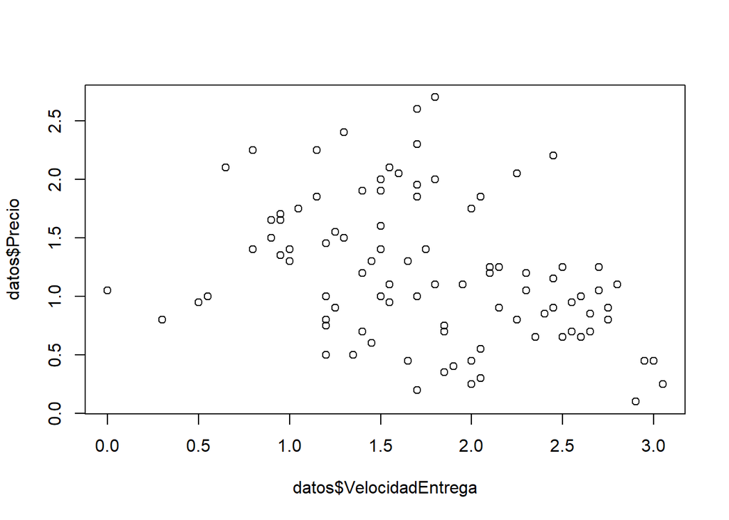

```r
plot(x=datos$VelocidadEntrega,y=datos$Precio)
```

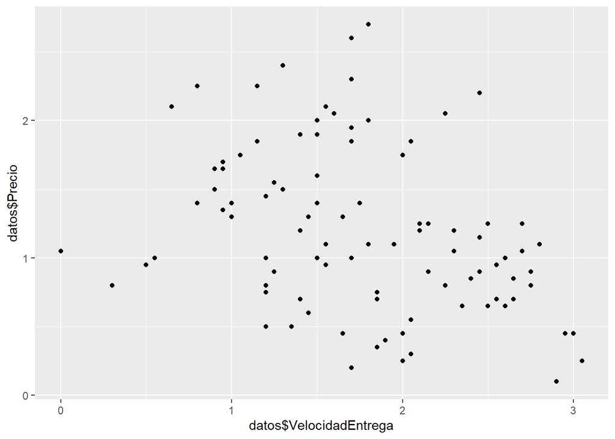

```r
qplot(x=datos$VelocidadEntrega,y=datos$Precio)
```

### 11.b

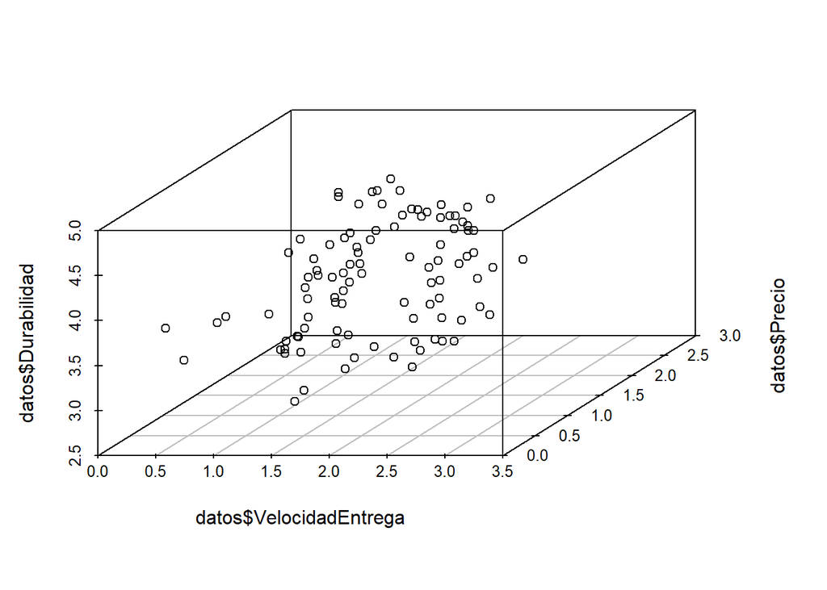

```r
library(scatterplot3d)

scatterplot3d(x=datos$VelocidadEntrega,y=datos$Precio, z=datos$Durabilidad)
```

### 11.c

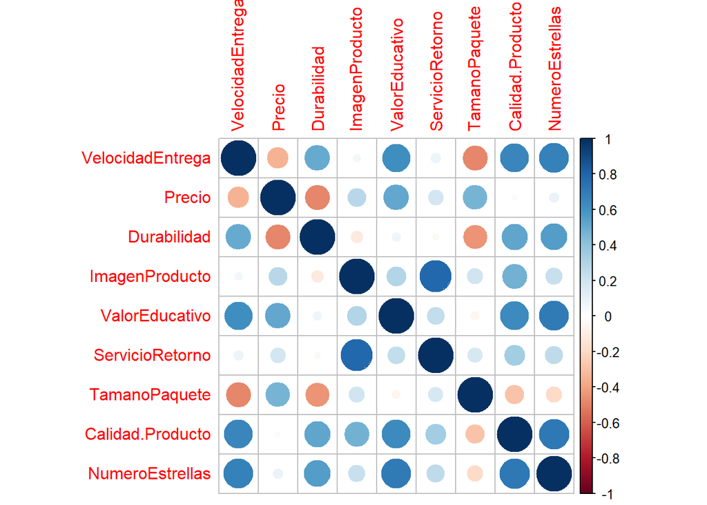

```r
library(corrplot)
matriz.cor<-cor(datos[,-1])

corrplot(matriz.cor)
```

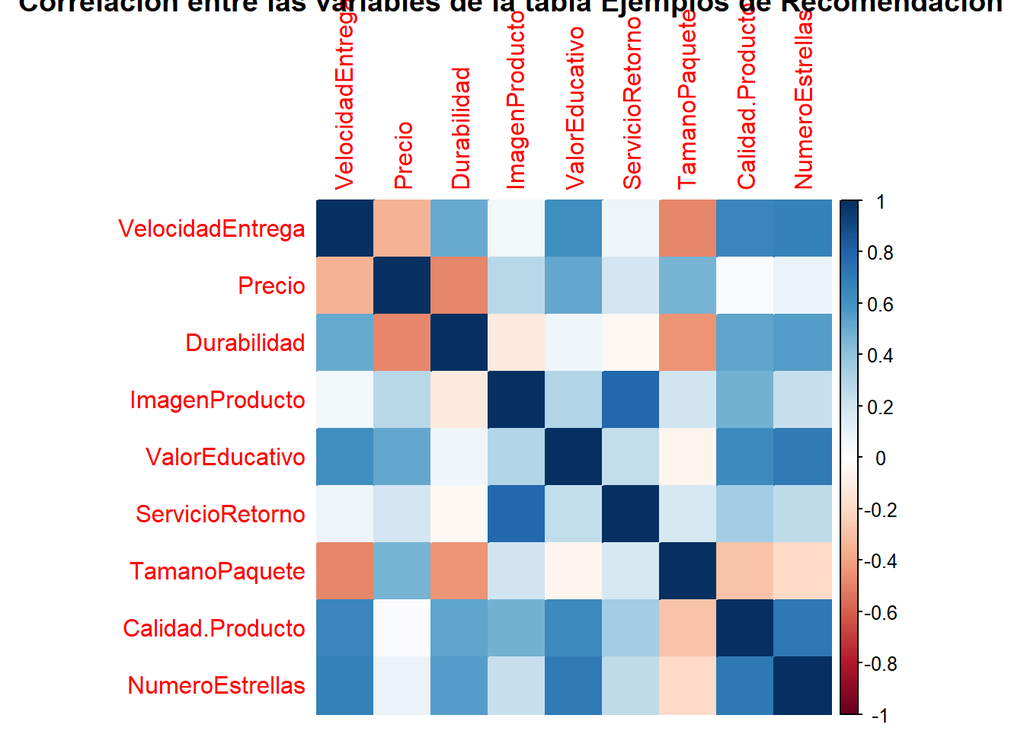

```r
corrplot(matriz.cor,
         method = "color",
         title = "Correlación entre las variables de la tabla Ejemplos de Recomendacion")
```

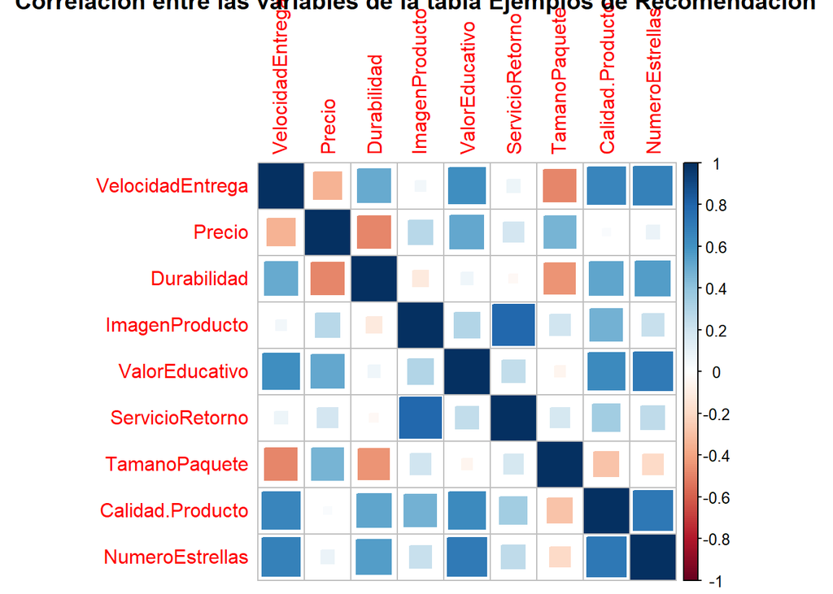

```r
corrplot(matriz.cor,
         method = "square",
         title = "Correlación entre las variables de la tabla Ejemplos de Recomendacion")
```

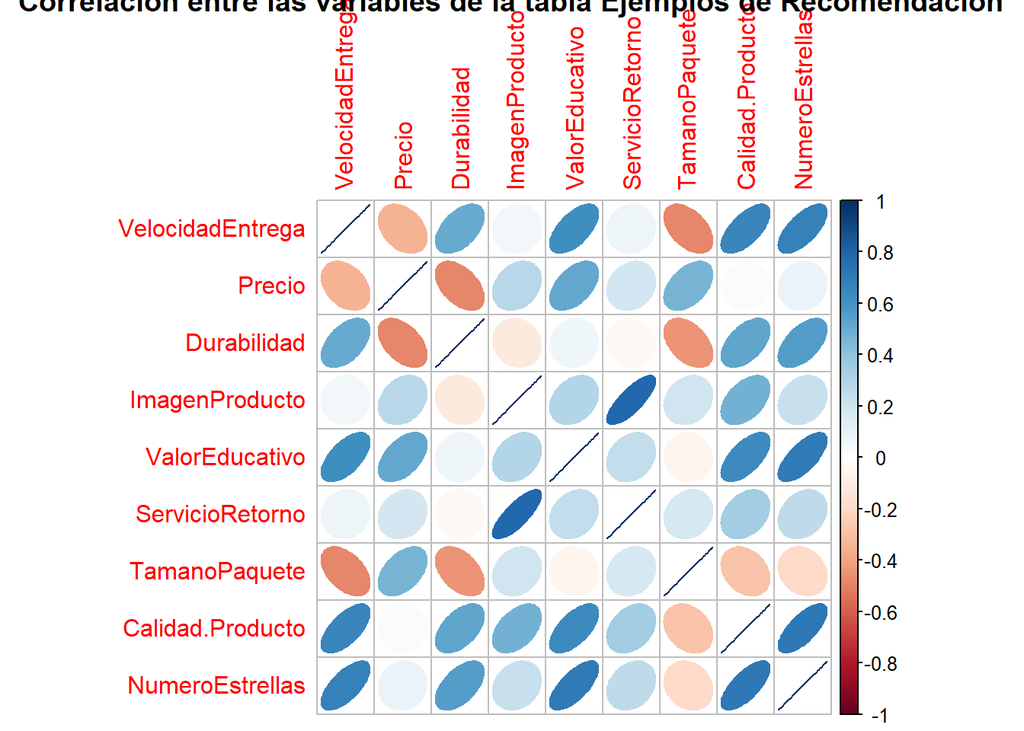

```r
corrplot(matriz.cor,
         method = "ellipse",
         title = "Correlación entre las variables de la tabla Ejemplos de Recomendacion")
```

### 11.d

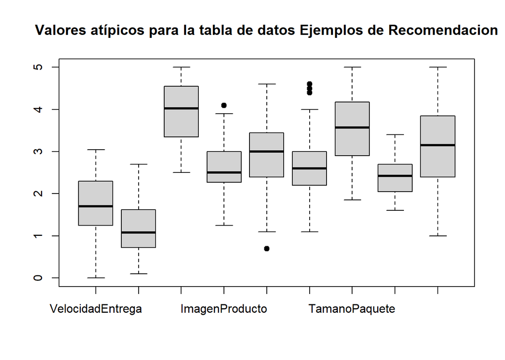

```r
boxplot(datos[,-1],
        outcol = "black",
        outpch = 19,
        main = "Valores atípicos para la tabla de datos Ejemplos de Recomendacion")
```

# ============================================

```r
setwd("~/ALEJANDRO/1er Ciclo 2023/Mineria de Datos/Tarea 1/DatosTarea1")
Datos <- read.table('SAheart.csv',header=TRUE, sep=';',dec=',')
```

### Calcule la dimensi´on de la Tabla de Datos.

```r
dim(Datos)
```

```
## [1] 462  10
```

### Despliegue las primeras 3 columnas de la tabla de datos.

```r
Datos[1:3]
```

```
##     sbp tobacco   ldl
## 1   160   12.00  5.73
## 2   144    0.01  4.41
## 3   118    0.08  3.48
## 4   170    7.50  6.41
## 5   134   13.60  3.50
## 6   132    6.20  6.47
## 7   142    4.05  3.38
## 8   114    4.08  4.59
## 9   114    0.00  3.83
## 10  132    0.00  5.80
## 11  206    6.00  2.95
## 12  134   14.10  4.44
## 13  118    0.00  1.88
## 14  132    0.00  1.87
```

[output cut: 448 more lines]

### Ejecute un summary y un str de los datos.

```r
summary(Datos)
```

```
##       sbp          tobacco              ldl             adiposity
##  Min.   :101.0   Length:462         Length:462         Length:462
##  1st Qu.:124.0   Class :character   Class :character   Class :character
##  Median :134.0   Mode  :character   Mode  :character   Mode  :character
##  Mean   :138.3
##  3rd Qu.:148.0
##  Max.   :218.0
##    famhist              typea        obesity            alcohol
##  Length:462         Min.   :13.0   Length:462         Length:462
##  Class :character   1st Qu.:47.0   Class :character   Class :character
##  Mode  :character   Median :53.0   Mode  :character   Mode  :character
##                     Mean   :53.1
##                     3rd Qu.:60.0
##                     Max.   :78.0
##       age            chd
##  Min.   :15.00   Length:462
##  1st Qu.:31.00   Class :character
##  Median :45.00   Mode  :character
##  Mean   :42.82
##  3rd Qu.:55.00
##  Max.   :64.00
```

```r
str(Datos)
```

```
## 'data.frame':    462 obs. of  10 variables:
##  $ sbp      : int  160 144 118 170 134 132 142 114 114 132 ...
##  $ tobacco  : chr  "12.00" " 0.01" " 0.08" " 7.50" ...
##  $ ldl      : chr  " 5.73" " 4.41" " 3.48" " 6.41" ...
##  $ adiposity: chr  "23.11" "28.61" "32.28" "38.03" ...
##  $ famhist  : chr  "Present" "Absent" "Present" "Present" ...
##  $ typea    : int  49 55 52 51 60 62 59 62 49 69 ...
##  $ obesity  : chr  "25.30" "28.87" "29.14" "31.99" ...
##  $ alcohol  : chr  " 97.20" "  2.06" "  3.81" " 24.26" ...
##  $ age      : int  52 63 46 58 49 45 38 58 29 53 ...
##  $ chd      : chr  "Si" "Si" "No" "Si" ...
```

### Usando el comando cor de R calcule la correlaci´on entre las variables tobacco y alcohol.

```r
cor(as.numeric(Datos$tobacco),as.numeric(Datos$alcohol))
```

```
## [1] 0.2008134
```

### Calcule la suma de las columnas con variables cuantitativas (num´ericas).

```r
cuantitativas<-sapply(Datos, is.numeric)
colSums(Datos[, cuantitativas])
```

```
##   sbp typea   age
## 63907 24534 19781
```

### Calcule para todas las variables cuantitativas presentes en el archivo SAheart.csv: El mınimo, el maximo, la media, la mediana y para la variables chd determine la cantidad de Si y de No.

```r
min(Datos[,1])
```

```
## [1] 101
```

```r
min(Datos[,2])
```

```
## [1] " 0.00"
```

```r
min(Datos[,3])
```

```
## [1] " 0.98"
```

```r
min(Datos[,4])
```

```
## [1] " 6.74"
```

```r
min(Datos[,6])
```

```
## [1] 13
```

```r
min(Datos[,7])
```

```
## [1] "14.70"
```

```r
min(Datos[,8])
```

```
## [1] "  0.00"
```

```r
min(Datos[,9])
```

```
## [1] 15
```

```r
max(Datos[,1])
```

```
## [1] 218
```

```r
max(Datos[,2])
```

```
## [1] "31.20"
```

```r
max(Datos[,3])
```

```
## [1] "15.33"
```

```r
max(Datos[,4])
```

```
## [1] "42.49"
```

```r
max(Datos[,6])
```

```
## [1] 78
```

```r
max(Datos[,7])
```

```
## [1] "46.58"
```

```r
max(Datos[,8])
```

```
## [1] "147.19"
```

```r
max(Datos[,9])
```

```
## [1] 64
```

```r
mean(Datos[,1])
```

```
## [1] 138.3268
```

```r
mean(Datos[,2])
```

```
## [1] NA
```

```r
mean(Datos[,3])
```

```
## [1] NA
```

```r
mean(Datos[,4])
```

```
## [1] NA
```

```r
mean(Datos[,6])
```

```
## [1] 53.1039
```

```r
mean(Datos[,7])
```

```
## [1] NA
```

```r
mean(Datos[,8])
```

```
## [1] NA
```

```r
mean(Datos[,9])
```

```
## [1] 42.81602
```

```r
median(Datos[,1])
```

```
## [1] 134
```

```r
median(Datos[,2])
```

```
## [1] NA
```

```r
median(Datos[,3])
```

```
## [1] NA
```

```r
median(Datos[,4])
```

```
## [1] NA
```

```r
median(Datos[,6])
```

```
## [1] 53
```

```r
median(Datos[,7])
```

```
## [1] NA
```

```r
median(Datos[,8])
```

```
## [1] NA
```

```r
median(Datos[,9])
```

```
## [1] 45
```

```r
cant.si<- Datos$chd == "Si"
sum(cant.si)
```

```
## [1] 160
```

```r
cant.si<- Datos$chd == "No"
sum(cant.si)
```

```
## [1] 302
```

# ============================================

## 13 Programe en R una funci´on que genera 200 n´umeros al azar entre 1 y 500 y luego calcula cuantos estan entre el 50 y 450, ambos inclusive

```r
ejercicio_13 <- function() {
  #genera 200 numeros entre 1 y 500
  numeros <- sample(1:500, 200, replace = TRUE)

  cantidad <- sum(numeros >= 50 & numeros <= 450)

  return(cantidad)
}


# Llamamos a la funcion
ejercicio_13()
```

```
## [1] 155
```

# ============================================

## Ejercicio 14 Desarrolle una funci´on que calcula el costo de una llamada telef´onica que ha durado t minutos sabiendo que si t < 1 el costo es de 0,4 d´olares, mientras que para duraciones superiores el costo es de 0,4 + (t − 1)/4 d´olares, la funci´on debe recibir el valor de t

```r
costo_llamada <- function(t) {
  if (t < 1) {
    costo <- 0.4
  } else {
    costo <- 0.4 + (t-1)/4
  }
  return(costo)
}

costo_llamada(2)
```

```
## [1] 0.65
```

# ============================================

## 15 Traza

```r
traza.matriz <- function(A) {
  filas <- nrow(A)
  traza <- 0
  for (i in 1:filas) {
    traza <- traza + A[i,i]
  }
  return(traza)
}
x<-matrix(data=c(9, 3, 4,1, 3, -1,4, 12, -2),nrow=3,ncol = 3, byrow = T)

traza.matriz(x)
```

```
## [1] 10
```

# ============================================

## Ejercicio 16 Fibonacci

```r
fibonacci <- function(n) {
  if (n <= 0) {
    return("")
  } else if (n == 1) {
    return(0)
  } else if (n == 2) {
    return(c(0, 1))
  } else {
    fibo <- c(0, 1)
    for (i in 3:n) {
      fibo[i] <- fibo[i-1] + fibo[i-2]
    }
    return(fibo)
  }
}
fibonacci(10)
```

```
##  [1]  0  1  1  2  3  5  8 13 21 34
```

# ============================================

## 17

```r
mayor.cuadrado <- function(x) {
  i <- 0
  while (i^2 <= x) {
    i <- i + 1
  }
  return((i-1)^2)
}
mayor.cuadrado(30)
```

```
## [1] 25
```

# ============================================

## 18

```r
datos_alumnos <- data.frame(
  nombre = c("Matias", "Alejandro", "Alexander", "Raquel", "Eduardo", "Sonia", "Juan", "Pablo", "Isaac", "Olga"),
  edad = c(16, 17, 14, 15, 17, 18, 16, 15, 16, 18),
  Año_nacimiento = 2023 - c(16, 17, 14, 15, 17, 18, 16, 15, 16, 18),
  Número_teléfono = c("65789431", "87654312", "76543891", "65456554", "89345632", "63549023", "73902345", "81230954", "63405623", "89645982"),
  row.names = c("Matias", "Alejandro", "Alexander", "Raquel", "Eduardo", "Sonia", "Juan", "Pablo", "Isaac", "Olga"))

# Mostramos el DataFrame creado
print(datos_alumnos)
```

```
##              nombre edad Año_nacimiento Número_teléfono
## Matias       Matias   16           2007        65789431
## Alejandro Alejandro   17           2006        87654312
## Alexander Alexander   14           2009        76543891
## Raquel       Raquel   15           2008        65456554
## Eduardo     Eduardo   17           2006        89345632
## Sonia         Sonia   18           2005        63549023
## Juan           Juan   16           2007        73902345
## Pablo         Pablo   15           2008        81230954
## Isaac         Isaac   16           2007        63405623
## Olga           Olga   18           2005        89645982
```

# ============================================

## Ejercicio 19

### 19.1 El numero de permutaciones con repeticion de r objetos tomados de n.

```r
ej.19.1 <- function(n, r) {
  n^r
}
ej.19.1(3,4)
```

```
## [1] 81
```

```r
ej.19.2<- function(n, r) {
  factorial(n) / factorial(n-r)
}

ej.19.1(4,3)
```

```
## [1] 64
```

### 19.3

```r
ej.19.3 <- function(n, k) {
  factorial(n) / prod(factorial(rep(n/k, k)))
}

ej.19.3(4,3)
```

```
## [1] 14.21905
```

### 19.4

```r
ej.19.4 <- function(n, r) {
  factorial(n) / (factorial(r) * factorial(n-r))
}

ej.19.4(4,3)
```

```
## [1] 4
```

### 19.5

```r
#ej.19.5 <- function(n, r) {
 # combs(n+r-1, r)
#}

#ej.19.5(4,3)
```

### 19.6

```r
#install.packages("gmp")
library(gmp)
Stirling2(4,3)
```

```
## Big Integer ('bigz') :
## [1] 6
```

# ====================================================

## Ejercicio 20 Desarrolle una funci´on R que recibe un DataFrame que retorna la cantidad de entradas de este DataFrame que son divisibles entre 3.

```r
divisibles.entre.3 <- function(df) {

  divisibles <- df %% 3 == 0

  cant <- sum(divisibles)

  return(cant)
}

df<-data.frame(x=c(1:7), y=c(7:13))

divisibles.entre.3(df)
```

```
## [1] 4
```

# ====================================================

## Ejercicio 21 Desarrolle una funcion R que recibe un DataFrame y dos numeros de columna y que retorna en una lista el nombre de las variables correspondientes a las columnas, la covarianza y la correlacion entre esas dos variables.

```r
cal.cov.cor <- function(df, col1, col2) {
  var1 <- colnames(df)[col1]
  var2 <- colnames(df)[col2]
  covar <- cov(df[,col1], df[,col2])
  correl <- cor(df[,col1], df[,col2])
  return(list(variables = c(var1, var2), covarianza = covar, correlacion = correl))
}

df<-data.frame(w=c(-9:0),x=c(1:10), y=c(11:20), z=c(21:30))

cal.cov.cor(df,2,3)
```

```
## $variables
## [1] "x" "y"
##
## $covarianza
## [1] 9.166667
##
## $correlacion
## [1] 1
```

# ====================================================

## Ejercicio 22 Importe directamente desde Excel en R el archivo EjemploAlgoritmosRecomendaci´on.xlsx el cual contiene los promedios de evaluaci´on de 100 personas que adquirieron los mismos productos o muy similares en la tienda AMAZON. Luego ejecute un str(…) y un summary(…) con esta tabla de datos

```r
#install.packages("readxl")
library(readxl)
setwd("~/ALEJANDRO/1er Ciclo 2023/Mineria de Datos/Tarea 1/DatosTarea1")
Datos <- read_xlsx('EjemploAlgoritmosRecomendacion.xlsx')
summary(Datos)
```

```
##      ...1           Velocidad Entrega     Precio        Durabilidad
##  Length:100         Min.   :0.000     Min.   :0.1000   Min.   :2.500
##  Class :character   1st Qu.:1.250     1st Qu.:0.7375   1st Qu.:3.350
##  Mode  :character   Median :1.700     Median :1.0750   Median :4.025
##                     Mean   :1.758     Mean   :1.1820   Mean   :3.947
##                     3rd Qu.:2.300     3rd Qu.:1.6125   3rd Qu.:4.550
##                     Max.   :3.050     Max.   :2.7000   Max.   :5.000
##  Imagen Producto Valor Educativo Servicio Retorno Tamano Paquete
##  Min.   :1.250   Min.   :0.700   Min.   :1.100    Min.   :1.850
##  1st Qu.:2.288   1st Qu.:2.400   1st Qu.:2.200    1st Qu.:2.900
##  Median :2.500   Median :3.000   Median :2.600    Median :3.575
##  Mean   :2.624   Mean   :2.916   Mean   :2.665    Mean   :3.486
##  3rd Qu.:3.000   3rd Qu.:3.425   3rd Qu.:3.000    3rd Qu.:4.162
##  Max.   :4.100   Max.   :4.600   Max.   :4.600    Max.   :5.000
##  Calidad Producto Numero Estrellas
##  Min.   :1.600    Min.   :1.000
##  1st Qu.:2.050    1st Qu.:2.400
##  Median :2.425    Median :3.150
##  Mean   :2.385    Mean   :3.110
##  3rd Qu.:2.700    3rd Qu.:3.825
##  Max.   :3.400    Max.   :5.000
```

```r
str(Datos)
```

```
## tibble [100 × 10] (S3: tbl_df/tbl/data.frame)
##  $ ...1             : chr [1:100] "Adam" "Anna" "Bernard" "Edward" ...
##  $ Velocidad Entrega: num [1:100] 2.05 0.9 1.7 1.35 3 0.95 2.3 0.65 2.75 2 ...
##  $ Precio           : num [1:100] 0.3 1.5 2.6 0.5 0.45 1.65 1.2 2.1 0.8 1.75 ...
##  $ Durabilidad      : num [1:100] 3.45 3.15 2.85 3.55 4.8 3.95 4.75 3.1 4.7 3.25 ...
##  $ Imagen Producto  : num [1:100] 2.35 3.3 3 2.95 3.9 2.4 3.3 2.55 2.35 3 ...
##  $ Valor Educativo  : num [1:100] 2.4 2.5 4.3 1.8 3.4 2.6 3.5 2.8 3.5 3.7 ...
##  $ Servicio Retorno : num [1:100] 2.3 4 2.7 2.3 4.6 1.9 4.5 2.2 3 3.2 ...
##  $ Tamano Paquete   : num [1:100] 2.6 4.2 4.1 3.9 2.25 4.85 3.8 3.45 3.8 4.35 ...
##  $ Calidad Producto : num [1:100] 2.1 2.15 2.6 1.95 3.4 2.2 2.9 2.15 2.7 2.7 ...
##  $ Numero Estrellas : num [1:100] 1.7 2.8 3.3 1.7 4.3 3 3.1 2.9 4.8 3.9 ...
```

# ====================================================

## Ejercicio 23

```r
U<-function(n){
  if(n==0) return(5)
  if(n==1) return(-5)
  if(n==2) return (2)
  else return(4*U(N-1) - 15*U(n-2)+U(n-3))
}
U(2)
```

```
## [1] 2
```

# ====================================================

## Ejercicio 24

```r
funcion <- function(x, n) {
  if (n == 0) {
    return(1)
  } else if (n == 1) {
    return(x)
  } else if (n > 1) {
    return(x * funcion(x, n-1))
  }
}

funcion(2,5)
```

```
## [1] 32
```

# ====================================================

## Ejercicio 25

```r
#install.packages("tidyr")
#library(tidyr)


#setwd("~/ALEJANDRO/1er Ciclo 2023/Mineria de Datos/Tarea 1/DatosTarea1")
#datos <- read.csv("bosques_energia.csv", header = TRUE)



#datos_tidy <- gather(datos, mes, valor, -nombre)
```